Client meeting notes -Theory: Among teammates born in the same year, the oldest (earliest-born) player tends to be physically bigger than peers, which boosts confidence and leads to genuinely better performance -Client’s ask: Test this theory statistically -Subject: Canadian hockey players born within the same year -Outcome variable: Whether the player made it into the NHL / whether the pattern differs by year -Main predictor: Birth month -What to look at: Distribution of how many players were born in each month -Potential confound: The general population itself has more births in January / early in the year, so this could create a false pattern unrelated to the theory — need to account for this baseline -Scope: Canadian players only -Data: Two Excel tables sharing player_id, but not the exact same set of players -Additional hypothesis: Client thinks birth month might relate to height -Additional question: Whether birth province matters -Note: Making the NHL itself is already a very high bar

## Stage 2: Make an analysis plan

- What model/test/technique you plan to use.

$$\chi^2 = \sum \frac{(observed -
expected)^2}{expected}$$

- A justification for that choice. This should consist of:
1. the probabilistic model you think describes the data :Assumed a Multinomial distribution.
1. NHL Birth-Month Distribution vs Canadian population(average bm Distribution)
2. year-matched birth-month distribution -> conclusion consistent
2. any simplifications of the model you are imposing to do your test/estimate parameters :full-period(1991–2022) average birth-month data
3. justifications of the simplifications. :Assumed birth-month pattern stable over time

#Stage3

```r
library(dplyr)
```

```r
library(tidyr)
library(ggplot2)
```

#- [ ] Get the data on your computer.

```r
data_cbirth <- read.csv(r"(C:\Users/hidy0/Desktop/consultation/Roster/canada_births_1991_2022.csv)")
data_cbirth
```

```
##     year month births
## 1   1991     1  32213
## 2   1991     2  30345
## 3   1991     3  34869
## 4   1991     4  35398
## 5   1991     5  36371
## 6   1991     6  34378
## 7   1991     7  35436
## 8   1991     8  34421
## 9   1991     9  34410
## 10  1991    10  33092
## 11  1991    11  30766
## 12  1991    12  32117
## 13  1992     1  31982
## 14  1992     2  31572
```

[output cut: 370 more lines]

```r
data_pbirth <- read.csv(r"(C:/Users/hidy0/Desktop/consultation/Roster/nhl_player_births.csv)")
data_pbirth
```

```
##      player_id     first_name           last_name birth_date
## 1      8467867          Bryan               Adams  3/20/1977
## 2      8445176         Donald             Audette  9/23/1969
## 3      8460014           Eric            Bertrand  4/16/1975
## 4      8460510          Jason           Botterill  5/19/1976
## 5      8459596         Andrew            Brunette  8/24/1973
## 6      8445733          Kelly          Buchberger  12/2/1966
## 7      8460573           Hnat        Domenichelli  2/17/1976
## 8      8459450          Shean             Donovan  1/22/1975
## 9      8446675         Nelson             Emerson  8/17/1967
## 10     8446823            Ray             Ferraro  8/23/1964
## 11     8447071          Johan           Garpenlov  3/21/1968
## 12     8460482        Stephen              Guolla  3/15/1973
## 13     8460524           Matt             Johnson 11/23/1975
## 14     8459571        Andreas            Karlsson  8/19/1975
```

[output cut: 25410 more lines]

#- [ ] Do quality checks (make sure it looks like what the client said it should). - Filter for Canadian players only -Check for missing values

```r
data_pbirth_can <- data_pbirth[data_pbirth$birth_country == "CAN",]
nrow(data_pbirth_can)
```

```
## [1] 5468
```

```r
sum(is.na(data_pbirth_can$birth_year))
```

```
## [1] 0
```

```r
sum(is.na(data_pbirth_can$birth_month))
```

```
## [1] 0
```

```r
sum(is.na(data_cbirth$year))
```

```
## [1] 0
```

```r
sum(is.na(data_cbirth$month))
```

```
## [1] 0
```

```r
sum(is.na(data_cbirth$births))
```

```
## [1] 0
```

Don’t cover the same time period -Overlapping period: 91-2005

```r
#full dataset
table(data_cbirth$year)
```

```
##
## 1991 1992 1993 1994 1995 1996 1997 1998 1999 2000 2001 2002 2003 2004 2005 2006
##   12   12   12   12   12   12   12   12   12   12   12   12   12   12   12   12
## 2007 2008 2009 2010 2011 2012 2013 2014 2015 2016 2017 2018 2019 2020 2021 2022
##   12   12   12   12   12   12   12   12   12   12   12   12   12   12   12   12
```

```r
table(data_cbirth$month)
```

```
##
##  1  2  3  4  5  6  7  8  9 10 11 12
## 32 32 32 32 32 32 32 32 32 32 32 32
```

```r
table(data_pbirth_can$birth_year)
```

```
##
## 1879 1881 1883 1884 1885 1886 1887 1888 1889 1890 1891 1892 1893 1894 1895 1896
##    1    1    2    1    5    3    6    4    4    8    9   13   13   14   16   15
## 1897 1898 1899 1900 1901 1902 1903 1904 1905 1906 1907 1908 1909 1910 1911 1912
##   15   18   15   20   14   23   18   22   28   29   23   22   25   26   26   24
## 1913 1914 1915 1916 1917 1918 1919 1920 1921 1922 1923 1924 1925 1926 1927 1928
##   22   36   28   37   23   32   29   22   32   24   34   33   35   28   38   34
## 1929 1930 1931 1932 1933 1934 1935 1936 1937 1938 1939 1940 1941 1942 1943 1944
##   38   28   32   34   40   38   33   32   27   36   24   35   31   32   40   29
## 1945 1946 1947 1948 1949 1950 1951 1952 1953 1954 1955 1956 1957 1958 1959 1960
##   50   51   51   63   78   72   53   80   72   80   84   76   86   81   69   95
## 1961 1962 1963 1964 1965 1966 1967 1968 1969 1970 1971 1972 1973 1974 1975 1976
##   82   80   91   80   89  103  101   87   95   72   71   67   68   60   84   78
## 1977 1978 1979 1980 1981 1982 1983 1984 1985 1986 1987 1988 1989 1990 1991 1992
##   74   56   64   78   62   58   74   70   90   64   64   60   62   69   66   61
## 1993 1994 1995 1996 1997 1998 1999 2000 2001 2002 2003 2004 2005
##   60   65   50   59   56   57   38   23   28   21    4    5    2
```

```r
table(data_pbirth_can$birth_month)
```

```
##
##   1   2   3   4   5   6   7   8   9  10  11  12
## 543 533 513 526 521 463 437 393 421 384 374 360
```

Visual comparison

```r
prop.table(tapply(data_cbirth$births, data_cbirth$month, sum))
```

```
##          1          2          3          4          5          6          7
## 0.08015265 0.07545096 0.08480224 0.08372814 0.08765969 0.08523528 0.08875414
##          8          9         10         11         12
## 0.08718995 0.08680416 0.08367415 0.07819978 0.07834886
```

```r
prop.table(table(data_pbirth_can$birth_month))
```

```
##
##          1          2          3          4          5          6          7
## 0.09930505 0.09747623 0.09381858 0.09619605 0.09528164 0.08467447 0.07991953
##          8          9         10         11         12
## 0.07187271 0.07699342 0.07022677 0.06839795 0.06583760
```

#- [ ] Get the data into the correct format for the function(s) you are going to use to fit the model.

Analysis1: using the average birth-month distribution

- Expected = total number of players × *the overall proportion*
- Observed = the actual number of NHL players for each month (across all years)

```r
observed <- table(data_pbirth_can$birth_month)
expected <- prop.table(tapply(data_cbirth$births, data_cbirth$month, sum))

chisq.test(observed, p=expected)
```

```
##
##  Chi-squared test for given probabilities
##
## data:  observed
## X-squared = 134.26, df = 11, p-value < 2.2e-16
```

H0: NHL bm distribution = Canada bm distribution

Check: monthly birth proportions are stable across years

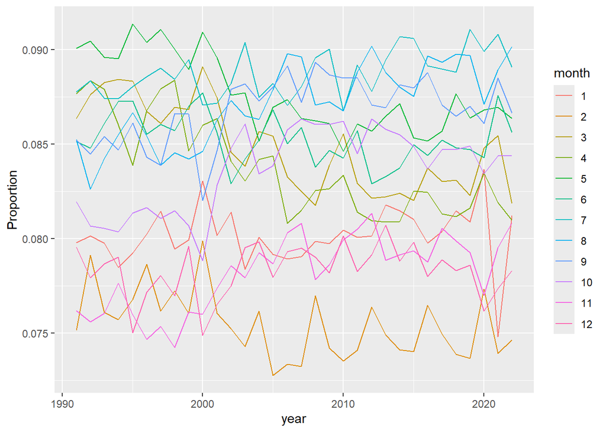

```r
cbirth_prop <- data_cbirth %>%
  group_by(year) %>%
  mutate(prop = births / sum(births))

ggplot(cbirth_prop,
       aes(year, prop, group=month, color = factor(month))) +
       geom_line() +
         labs(x = "year", y = "Proportion", color = "month")
```

```r
year_month_table <- xtabs(births ~ year + month, data_cbirth)
chisq.test(year_month_table)
```

```
##
##  Pearson's Chi-squared test
##
## data:  year_month_table
## X-squared = 5767.9, df = 341, p-value < 2.2e-16
```

-> Canadian birth-month pattern was not exactly the same every year (= the proportion of babies born each month in Canada can vary from year to year)

Analysis2: overlapping years(91-2005) -> using year-matched birth distributions - Expected = that year’s total number of players × *that year’s Canadian birth proportion* - Observed = the actual number of NHL players for each year and month.

```r
#91-2005 Candanian
exact_cbirth <- data_cbirth[data_cbirth$year >= 1991
                            & data_cbirth$year <= 2005, ]

#Canadian bm proportions
exact_cbirth_prop <- exact_cbirth %>%
  group_by(year) %>%
  mutate(prop = births / sum(births))

#91-2005 Candanian players
exact_pbirth <- data_pbirth_can[data_pbirth_can$birth_year>= 1991 & data_pbirth_can$birth_year <= 2005, ]

#Canadian player monthly birth proportions
exact_pbirth_count <- exact_pbirth %>%
  group_by(birth_year, birth_month) %>%
  summarise(observed = n(), .groups = "drop") %>%
  complete(birth_year = 1991:2005, birth_month = 1:12, fill = list(observed = 0))

exact_pbirth_merge <- exact_pbirth_count %>%
  left_join(exact_cbirth_prop, by = c("birth_year"="year",
                                      "birth_month"="month"))

head(exact_pbirth_merge)
```

```
## # A tibble: 6 × 5
##   birth_year birth_month observed births   prop
##        <int>       <int>    <int>  <int>  <dbl>
## 1       1991           1       13  32213 0.0798
## 2       1991           2        7  30345 0.0751
## 3       1991           3        3  34869 0.0863
## 4       1991           4        4  35398 0.0877
## 5       1991           5        9  36371 0.0901
## 6       1991           6        3  34378 0.0851
```

Intermediate table: NHL counts & Canadian birth proportions

```r
# number of players per year
year_totals <- tapply(exact_pbirth_merge$observed, exact_pbirth_merge$birth_year, sum)

exact_pbirth_merge$n_i <- year_totals[as.character(exact_pbirth_merge$birth_year)]

#expected count
exact_pbirth_merge$expected_ij <- exact_pbirth_merge$n_i * exact_pbirth_merge$prop


#chi
observed_by_month <- tapply(exact_pbirth_merge$observed, exact_pbirth_merge$birth_month, sum)
expected_by_month <- tapply(exact_pbirth_merge$expected_ij, exact_pbirth_merge$birth_month, sum)

chisq.test(observed_by_month, p = expected_by_month / sum(expected_by_month))
```

```
##
##  Chi-squared test for given probabilities
##
## data:  observed_by_month
## X-squared = 67.628, df = 11, p-value = 3.441e-10
```

H0: NHL distribution = Canada distribution

Both analyses -> NHL distribution ≠ Canadian distribution (theory)

First method (average proportion)

*Residual = Observed−Expected

```r
observed <- table(data_pbirth_can$birth_month)
expected_p <- prop.table(tapply(data_cbirth$births, data_cbirth$month, sum))
result <- chisq.test(observed, p = expected_p)

sort( result$stdres, decreasing=TRUE)
```

```
##
##          2          1          4          3          5          6          7
##  6.1664887  5.2157945  3.3285891  2.3932258  1.9929748 -0.1485138 -2.2971507
##          9         11         12         10          8
## -2.5766999 -2.6996036 -3.4428317 -3.5911313 -4.0148671
```

Players born earlier in the year are more common in the NHL than expected.

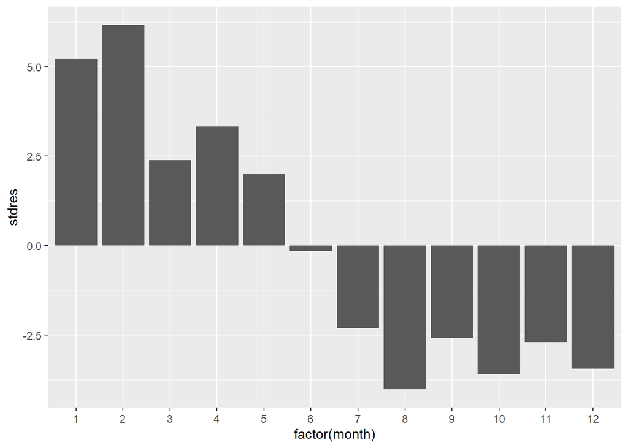

```r
stdres_table <- data.frame(month = as.numeric(names(result$stdres)),
                           stdres = as.numeric(result$stdres))

ggplot(stdres_table, aes(x=factor(month), y = stdres)) +
  geom_col()
```

Check: downward trend

```r
observed_by_month <- as.numeric(table(data_pbirth_can$birth_month))
expected_p <- as.numeric(prop.table(tapply(data_cbirth$births, data_cbirth$month, sum)))
n_total <- sum(observed_by_month)

prop.trend.test(observed_by_month, rep(n_total, 12), score = 1:12)
```

```
##
##  Chi-squared Test for Trend in Proportions
##
## data:  observed_by_month out of rep(n_total, 12) ,
##  using scores: 1 2 3 4 5 6 7 8 9 10 11 12
## X-squared = 116.77, df = 1, p-value < 2.2e-16
```

H0: no consistent trend in the monthly proportion

Result: NHL players were more likely to be born earlier in the year, and less likely to born later in the year. -> theory

## Stage 2: Make an analysis plan

- What model/test/technique you plan to use. linear regression

## Stage 3: Perform the analysis

- Get the data on your computer.

```r
data_roster <- read.csv(r"(C:/Users/hidy0/Desktop/consultation/Roster/nhl_rosters.csv)")
data_roster
```

```
##      team_code   season position_type player_id
## 1          ATL 19992000      forwards   8467867
## 2          ATL 19992000      forwards   8445176
## 3          ATL 19992000      forwards   8460014
## 4          ATL 19992000      forwards   8460510
## 5          ATL 19992000      forwards   8459596
## 6          ATL 19992000      forwards   8445733
## 7          ATL 19992000      forwards   8460573
## 8          ATL 19992000      forwards   8459450
## 9          ATL 19992000      forwards   8446675
## 10         ATL 19992000      forwards   8446823
## 11         ATL 19992000      forwards   8447071
## 12         ATL 19992000      forwards   8460482
## 13         ATL 19992000      forwards   8460524
## 14         ATL 19992000      forwards   8459571
```

[output cut: 33322 more lines]

- Do quality checks Duplicates in the roster-> removed

```r
data_roster_canada <- data_roster[data_roster$birth_country == "CAN",]

data_roster_can <- data_roster_canada[!duplicated(data_roster_canada$player_id),]

nrow(data_pbirth_can)
```

```
## [1] 5468
```

```r
nrow(data_roster_can)
```

```
## [1] 5468
```

height & birth date

```r
sum(is.na(data_roster_can$height_in_centimeters))
```

```
## [1] 8
```

```r
sum(is.na(data_roster_can$birth_date))
```

```
## [1] 0
```

```r
data_roster_can <- data_roster_can[!is.na(data_roster_can$height_in_centimeters), ]

nrow(data_roster_can)
```

```
## [1] 5460
```

- Get the data into the correct format for the function(s) you are going to use to fit the model.

:birth_date format is inconsistent -> 160 NA

```r
data_roster_can$birth_month <- as.numeric(format(as.Date(data_roster_can$birth_date,
format = "%m/%d/%Y"), "%m"))

#Birth month gets split into quarters
data_roster_can$birth_quarter <- cut(data_roster_can$birth_month,
    breaks = c(0, 3, 6, 9, 12),
    labels = c("Q1", "Q2", "Q3", "Q4"))

height_quarter_data <- data_roster_can[, c("height_in_centimeters", "birth_quarter")]

height_quarter_data
```

```
##       height_in_centimeters birth_quarter
## 1                       183            Q1
## 2                       173            Q3
## 3                       185            Q2
## 4                       193            Q2
## 5                       185            Q3
## 6                       188            Q4
## 7                       183            Q1
## 8                       191            Q1
## 9                       178            Q3
## 10                      175            Q3
## 12                      183            Q1
## 13                      196            Q4
## 15                      180            Q1
## 17                      178            Q2
```

[output cut: 5446 more lines]

```r
colSums(is.na(height_quarter_data))
```

```
## height_in_centimeters         birth_quarter
##                     0                   160
```

```r
height_quarter_data <- height_quarter_data[!is.na(height_quarter_data$birth_quarter), ]
```

- Fit the model, get the number(s) you need from the output.

```r
model_h <- lm(height_in_centimeters ~ birth_quarter, height_quarter_data)
summary(model_h)
```

```
##
## Call:
## lm(formula = height_in_centimeters ~ birth_quarter, data = height_quarter_data)
##
## Residuals:
##      Min       1Q   Median       3Q      Max
## -22.2934  -4.2934   0.1328   4.9490  20.7066
##
## Coefficients:
##                 Estimate Std. Error  t value Pr(>|t|)
## (Intercept)     182.8672     0.1530 1195.325   <2e-16 ***
## birth_quarterQ2   0.1838     0.2187    0.840   0.4008
## birth_quarterQ3  -0.3001     0.2302   -1.304   0.1924
## birth_quarterQ4  -0.5738     0.2383   -2.408   0.0161 *
## ---
## Signif. codes:  0 '***' 0.001 '**' 0.01 '*' 0.05 '.' 0.1 ' ' 1
##
## Residual standard error: 5.996 on 5296 degrees of freedom
## Multiple R-squared:  0.002191,   Adjusted R-squared:  0.001626
## F-statistic: 3.876 on 3 and 5296 DF,  p-value: 0.008818
```

- Q4 is 0.57 shorter than Q1: (statistically significant)
- R² = 0.2%

= Birth quarter explains very little of the height difference

Check regression assumptions

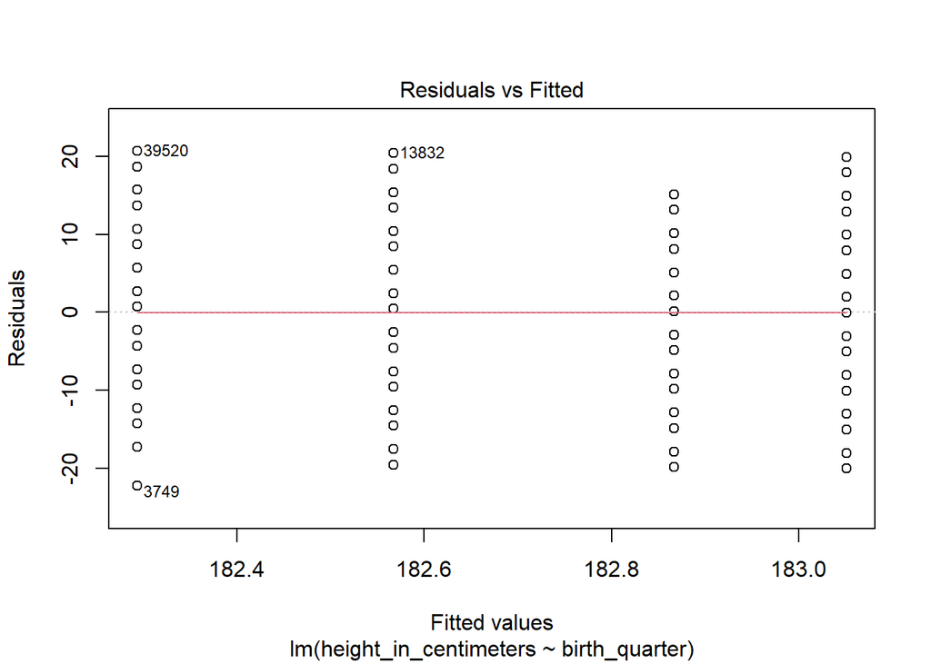

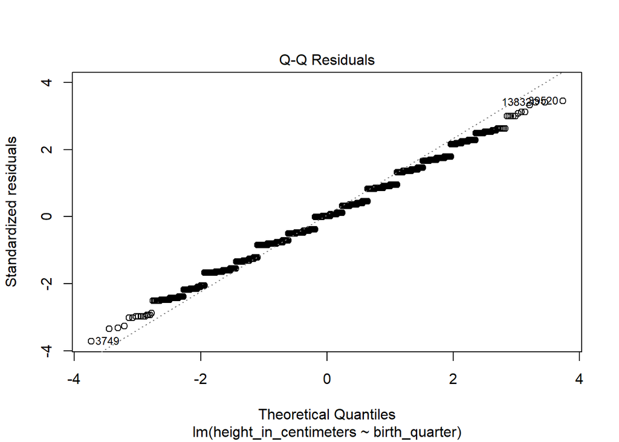

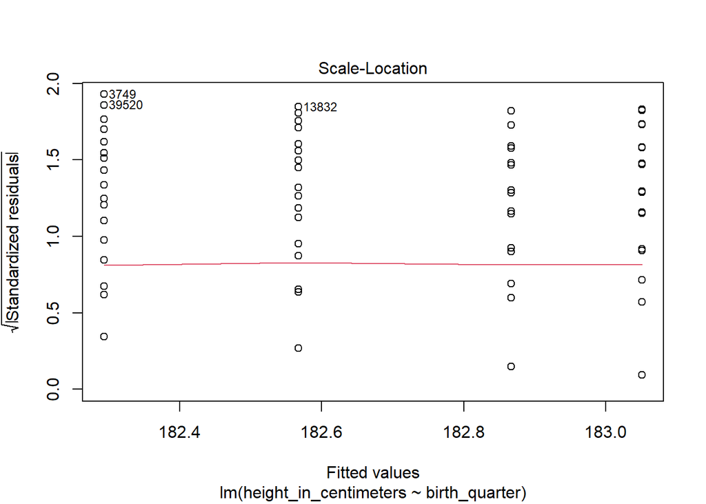

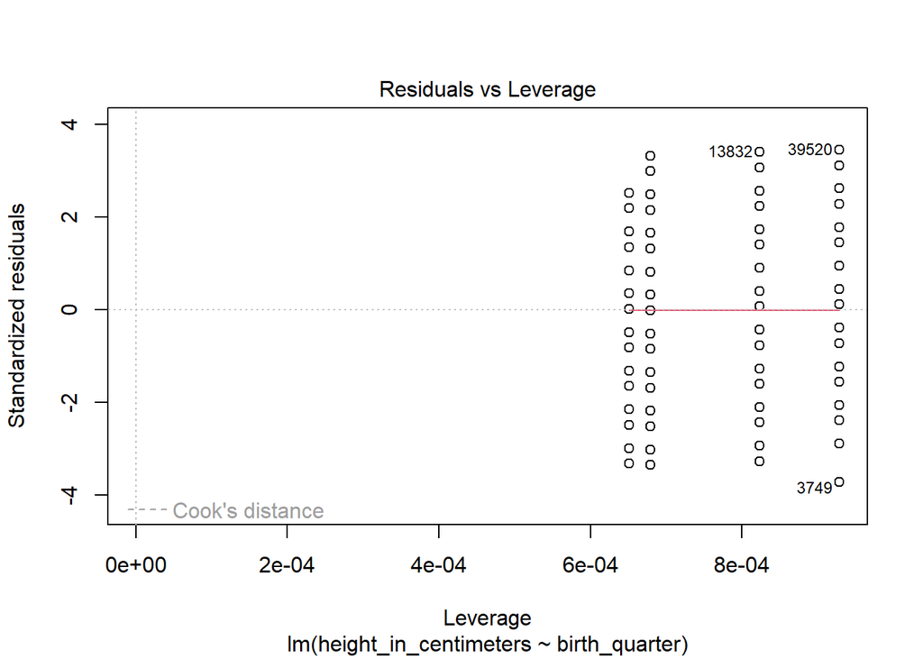

```r
plot(model_h)
```